# AR(1) scenarios of real returns

```julia
# Defaults for running the cells outside Quarto. Under `quarto render` the front-matter
# `params` (overridden by `-P name:value` or `--execute-params file.yml`, see
# render_ar1_reports.sh) are already defined as constants, so these assignments are skipped.
@isdefined(params_file) || (params_file = "specs/ar1/hist1935-2025.yaml")
@isdefined(T) || (T = 100)                      # simulated years
@isdefined(horizons) || (horizons = [1, 5, 10, 20, 30, 50, 100])  # horizon table years, ≤ T
@isdefined(n_scen) || (n_scen = 10000)
@isdefined(seed) || (seed = 1234)
```

```julia
import Pkg
Pkg.activate(joinpath(@__DIR__, "..", ".."); io = devnull)

using MacroFinanceScenarios
using MacroFinanceScenarios.IbbotsonSinquefield
using MacroFinanceScenarios.EDA
using MacroFinanceScenarios.ScenariosEvaluation
using CSV, DataFrames, Dates, Random, Statistics, TimeSeries
using Plots

show_table(t; title = "", digits = 2) =
    display(HTML(sprint(io -> print_table(io, t; backend = :html, digits, title))))

# Everything loaded and computed is in decimal log units; the report shows percent. Means,
# std and percentiles scale by 100; skewness, kurtosis, autocorrelations and correlations
# do not, and `neg` (share of negative values) is already in percent.
pct(sc::Scenarios) = Scenarios(100 .* sc.data, sc.names, sc.start_year)
function pct(df::DataFrame; cols)
    out = copy(df)
    for c in cols
        out[!, c] = 100 .* out[!, c]
    end
    return out
end
moment_cols = [:mean, :std, :min, :p25, :p50, :p75, :max]   # describe_series columns in %
span(p) = "$(p[1])–$(p[2])"

p = load_ar1_params(joinpath(@__DIR__, params_file))
comps = p.names                     # [:r, :tp, :xr]
vars = [:r, :rb_real, :re_real]     # real returns built from them
```

## Model and parameters

Three annual log variables, each an AR(1) `x_t = c + φ x_{t-1} + σ ε_t`, with shocks `ε_t` i.i.d. `N(0, C)` across years:

- the real T-bill return `r`, with its AR(1) fit (intercept and lag coefficient);
- the excess bond return `tp = rb − rf` and the excess equity return `xr = re − rf`, intercept only (`φ = 0`): i.i.d. around their sample mean, as erp in the Ibbotson–Sinquefield model.

The real returns are `r`, `rb_real = r + tp` and `re_real = r + xr`. Parameters are read from specs/ar1/hist1935-2025.yaml, estimated over 1935–2025 (the first year is lost to the lag).

```julia
mp = DataFrame(p.model_params)
mp.uncond_mean = unconditional_mean.(p.models)
mp.uncond_std = unconditional_std.(p.models)
mp.y0 = p.y0
show_table(pct(mp; cols = [:c, :se_c, :sigma, :uncond_mean, :uncond_std, :y0]); digits = 3,
           title = "AR(1) parameters (c, σ, means, y0 in %)")
show_table(insertcols!(DataFrame(p.C, String.(comps)), 1, :variable => String.(comps));
           title = "Shock correlation C")
show_table(DataFrame(parameter = ["params file", "first simulated year", "simulated years",
                                  "scenarios", "seed"],
                     value = [params_file, string(p.start_year), string(T), string(n_scen),
                              string(seed)]);
           title = "Simulation")
```

| AR(1) parameters (c, σ, means, y0 in %) variable String | AR(1) parameters (c, σ, means, y0 in %) n Int64 | AR(1) parameters (c, σ, means, y0 in %) c Float64 | AR(1) parameters (c, σ, means, y0 in %) se_c Float64 | AR(1) parameters (c, σ, means, y0 in %) phi Float64 | AR(1) parameters (c, σ, means, y0 in %) se_phi Float64 | AR(1) parameters (c, σ, means, y0 in %) sigma Float64 | AR(1) parameters (c, σ, means, y0 in %) r2 Float64 | AR(1) parameters (c, σ, means, y0 in %) uncond_mean Float64 | AR(1) parameters (c, σ, means, y0 in %) uncond_std Float64 | AR(1) parameters (c, σ, means, y0 in %) y0 Float64 |
| --- | --- | --- | --- | --- | --- | --- | --- | --- | --- | --- |
| r | 90.0 | -0.023 | 0.307 | 0.551 | 0.089 | 2.907 | 0.305 | -0.05 | 3.484 | 1.539 |
| tp | 90.0 | 1.112 | 0.676 | 0.0 | 0.0 | 6.409 | 0.0 | 1.112 | 6.409 | 1.883 |
| xr | 90.0 | 6.861 | 1.731 | 0.0 | 0.0 | 16.422 | 0.0 | 6.861 | 16.422 | 10.054 |

| Shock correlation C variable String | Shock correlation C r Float64 | Shock correlation C tp Float64 | Shock correlation C xr Float64 |
| --- | --- | --- | --- |
| r | 1.0 | 0.21 | 0.15 |
| tp | 0.21 | 1.0 | 0.02 |
| xr | 0.15 | 0.02 | 1.0 |

| Simulation parameter String | Simulation value String |
| --- | --- |
| params file | specs/ar1/hist1935-2025.yaml |
| first simulated year | 2026 |
| simulated years | 100 |
| scenarios | 10000 |
| seed | 1234 |

Units: returns and moments below are annual log values in percent, except where a table or chart says *simple rate* (`exp(·) − 1` of the log rate, in percent) or *wealth* (of 1 invested); skewness, excess kurtosis, autocorrelations and correlations are unit-free.

## Historical data and fitted values

```julia
raw = TimeArray(CSV.File(joinpath(@__DIR__, "..", "..", "data", "shiller_annual.csv"));
                timestamp = :timestamp)
data = subperiod(raw[union(comps, vars)...], p.ar_period)
yrs = year.(timestamp(data))
```

```
91-element Vector{Int64}:
 1935
 1936
 1937
 1938
 1939
 1940
 1941
 1942
 1943
 1944
    ⋮
 2017
 2018
 2019
 2020
 2021
 2022
 2023
 2024
 2025
```

The real short rate and its one-step-ahead fitted values `c + φ r_{t-1}` with the loaded parameters; the dashed line is the unconditional mean.

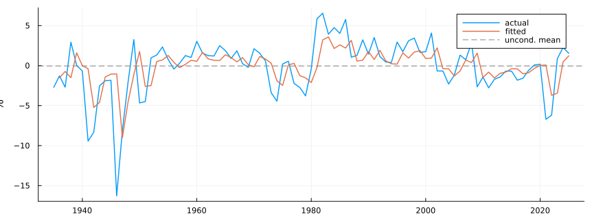

Real T-bill return: actual and AR(1) fitted values

```julia
ar_r = p.models[findfirst(==(:r), comps)]
r_hist = vec(values(data[:r]))
r_fit = ar_r.c .+ ar_r.φ .* r_hist[1:end-1]
plt = plot(yrs, 100r_hist; label = "actual", lw = 1.5, ylabel = "%", legend = :topright, size = (900, 330))
plot!(plt, yrs[2:end], 100r_fit; label = "fitted", lw = 1.5)
hline!(plt, [100unconditional_mean(ar_r)]; ls = :dash, color = :gray, label = "uncond. mean")
plt
```

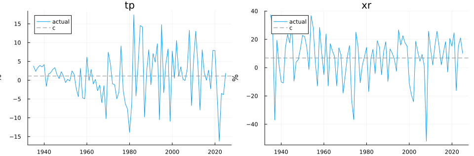

Excess returns and their intercepts

```julia
plot([begin
          x = vec(values(data[v]))
          m = p.models[findfirst(==(v), comps)]
          plot(yrs, 100x; label = "actual", title = String(v), ylabel = "%", legend = :topleft)
          hline!([100m.c]; ls = :dash, color = :gray, label = "c")
      end for v in (:tp, :xr)]...; layout = (1, 2), size = (1000, 330))
```

```julia
hist_moments = describe_series(data[vars...])
hist_cor = correlation_table(data[vars...])
hist_pct = pct(hist_moments; cols = moment_cols)
show_table(hist_pct; title = "Historical real returns, $(span(p.ar_period))")
show_table(pct(describe_series(data[comps...]); cols = moment_cols);
           title = "Historical components, $(span(p.ar_period))")
show_table(hist_cor; title = "Correlations, $(span(p.ar_period))")
```

| Historical real returns, 1935–2025 variable String | Historical real returns, 1935–2025 mean Float64 | Historical real returns, 1935–2025 std Float64 | Historical real returns, 1935–2025 skewness Float64 | Historical real returns, 1935–2025 ex_kurtosis Float64 | Historical real returns, 1935–2025 ar1 Float64 | Historical real returns, 1935–2025 neg Float64 | Historical real returns, 1935–2025 min Float64 | Historical real returns, 1935–2025 p5 Float64 | Historical real returns, 1935–2025 p25 Float64 | Historical real returns, 1935–2025 p50 Float64 | Historical real returns, 1935–2025 p75 Float64 | Historical real returns, 1935–2025 p95 Float64 | Historical real returns, 1935–2025 max Float64 |
| --- | --- | --- | --- | --- | --- | --- | --- | --- | --- | --- | --- | --- | --- |
| r | -0.14 | 3.46 | -1.5 | 4.56 | 0.55 | 41.76 | -16.28 | -0.06 | -1.77 | 0.46 | 1.74 | 0.04 | 6.54 |
| rb_real | 1.0 | 8.03 | 0.11 | 0.56 | 0.1 | 42.86 | -22.41 | -0.11 | -3.68 | 0.96 | 5.25 | 0.14 | 23.94 |
| re_real | 7.06 | 17.29 | -0.96 | 0.83 | -0.02 | 28.57 | -49.11 | -0.25 | -2.04 | 11.45 | 18.0 | 0.29 | 39.12 |

| Historical components, 1935–2025 variable String | Historical components, 1935–2025 mean Float64 | Historical components, 1935–2025 std Float64 | Historical components, 1935–2025 skewness Float64 | Historical components, 1935–2025 ex_kurtosis Float64 | Historical components, 1935–2025 ar1 Float64 | Historical components, 1935–2025 neg Float64 | Historical components, 1935–2025 min Float64 | Historical components, 1935–2025 p5 Float64 | Historical components, 1935–2025 p25 Float64 | Historical components, 1935–2025 p50 Float64 | Historical components, 1935–2025 p75 Float64 | Historical components, 1935–2025 p95 Float64 | Historical components, 1935–2025 max Float64 |
| --- | --- | --- | --- | --- | --- | --- | --- | --- | --- | --- | --- | --- | --- |
| r | -0.14 | 3.46 | -1.5 | 4.56 | 0.55 | 41.76 | -16.28 | -0.06 | -1.77 | 0.46 | 1.74 | 0.04 | 6.54 |
| tp | 1.14 | 6.38 | 0.01 | 0.32 | -0.06 | 40.66 | -16.22 | -0.1 | -2.73 | 1.48 | 4.17 | 0.13 | 17.4 |
| xr | 7.2 | 16.64 | -0.95 | 1.1 | -0.03 | 27.47 | -51.97 | -0.21 | -2.8 | 11.06 | 17.92 | 0.28 | 37.38 |

| Correlations, 1935–2025 variable String | Correlations, 1935–2025 r Float64 | Correlations, 1935–2025 rb_real Float64 | Correlations, 1935–2025 re_real Float64 |
| --- | --- | --- | --- |
| r | 1.0 | 0.64 | 0.28 |
| rb_real | 0.64 | 1.0 | 0.18 |
| re_real | 0.28 | 0.18 | 1.0 |

## Simulation

The simulation starts from `y0`, the state in 2025; `r` reverts to its unconditional mean at rate `φ`, while `tp` and `xr` have no memory. No moment matching is applied: the gap between the achieved mean and the unconditional mean is sampling noise plus the effect of the starting point, `se` is the std of the per-path means / √n_scen.

```julia
sc_comp = simulate_ar1(p, T, n_scen; rng = MersenneTwister(seed))
comp(v) = sc_comp[v]                                         # T × n_scen
rets = cat(comp(:r), comp(:r) .+ comp(:tp), comp(:r) .+ comp(:xr); dims = 3)
sc = Scenarios(permutedims(rets, (3, 1, 2)), vars, sc_comp.start_year)

μ_c = Dict(zip(comps, unconditional_mean.(p.models)))
μ_target = Dict(:r => μ_c[:r], :rb_real => μ_c[:r] + μ_c[:tp], :re_real => μ_c[:r] + μ_c[:xr])

path_means = dropdims(mean(sc.data; dims = 2); dims = 2)   # n_vars × n_scen
achieved = DataFrame(variable = String.(vars),
                     uncond_mean = 100 .* [μ_target[v] for v in vars],
                     simulated = 100vec(mean(path_means; dims = 2)),
                     se = 100vec(std(path_means; dims = 2)) ./ sqrt(n_scen))
achieved.z = (achieved.simulated .- achieved.uncond_mean) ./ achieved.se
show_table(achieved; title = "Mean over all years and paths vs. unconditional mean (%)")
println("Simulated years $(first(scenario_years(sc)))–$(last(scenario_years(sc))).")
```

```
Simulated years 2026–2125.
```

| Mean over all years and paths vs. unconditional mean (%) variable String | Mean over all years and paths vs. unconditional mean (%) uncond_mean Float64 | Mean over all years and paths vs. unconditional mean (%) simulated Float64 | Mean over all years and paths vs. unconditional mean (%) se Float64 | Mean over all years and paths vs. unconditional mean (%) z Float64 |
| --- | --- | --- | --- | --- |
| r | -0.05 | -0.03 | 0.01 | 2.44 |
| rb_real | 1.06 | 1.08 | 0.01 | 1.72 |
| re_real | 6.81 | 6.83 | 0.02 | 0.89 |

## Fan charts

5–95 and 25–75 percentile bands, median, and the unconditional mean (dashed).

```julia
fans(vars; kwargs...) = [fan(sc, v; μ = μ_target[v], kwargs...) for v in vars]
```

```
fans (generic function with 1 method)
```

### Annual returns

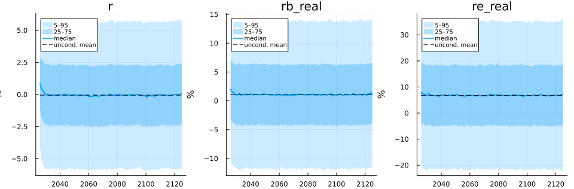

Annual log real returns

```julia
plot(fans(vars; scale = 100)...; layout = (1, length(vars)), size = (1000, 330), ylabel = "%")
```

### Cumulative wealth

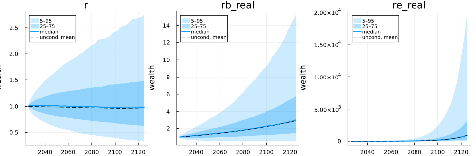

Wealth of 1 invested, real

```julia
plot(fans(vars; kind = :wealth)...; layout = (1, length(vars)), size = (1000, 330), ylabel = "wealth")
```

### Annualised returns

Geometric-average annual return over the first `h` years, `exp(sum(x_1..h)/h) − 1`.

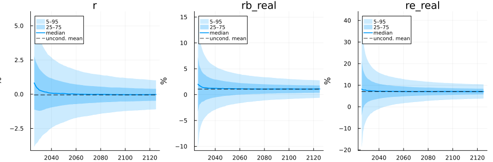

Annualised simple real rates

```julia
plot(fans(vars; kind = :annualised, simple = true, scale = 100)...;
     layout = (1, length(vars)), size = (1000, 330), ylabel = "%")
```

## Evaluation

### Per-path moments

Statistics computed within each simulated path, then summarised across scenarios; the `historical` column is the historical sample. `neg` is the percent of years with a negative value.

```julia
for (name, t) in path_moments(pct(sc); hist = hist_pct)
    show_table(t; title = String(name))
end
```

| r statistic String | r historical Float64 | r mean Float64 | r p5 Float64 | r p25 Float64 | r p50 Float64 | r p75 Float64 | r p95 Float64 |
| --- | --- | --- | --- | --- | --- | --- | --- |
| mean | -0.14 | -0.03 | -1.1 | -0.47 | -0.02 | 0.39 | 1.01 |
| std | 3.46 | 3.42 | 2.91 | 3.19 | 3.41 | 3.63 | 3.98 |
| skewness | -1.5 | 0.0 | -0.43 | -0.17 | -0.0 | 0.18 | 0.44 |
| ex_kurtosis | 4.56 | -0.1 | -0.69 | -0.41 | -0.18 | 0.13 | 0.73 |
| ar1 | 0.55 | 0.52 | 0.37 | 0.46 | 0.52 | 0.58 | 0.65 |
| neg | 41.76 | 50.4 | 37.0 | 45.0 | 50.0 | 56.0 | 64.0 |

| rb_real statistic String | rb_real historical Float64 | rb_real mean Float64 | rb_real p5 Float64 | rb_real p25 Float64 | rb_real p50 Float64 | rb_real p75 Float64 | rb_real p95 Float64 |
| --- | --- | --- | --- | --- | --- | --- | --- |
| mean | 1.0 | 1.08 | -0.58 | 0.4 | 1.09 | 1.76 | 2.72 |
| std | 8.03 | 7.74 | 6.83 | 7.36 | 7.73 | 8.12 | 8.68 |
| skewness | 0.11 | -0.0 | -0.38 | -0.16 | -0.0 | 0.16 | 0.39 |
| ex_kurtosis | 0.56 | -0.06 | -0.65 | -0.37 | -0.13 | 0.17 | 0.77 |
| ar1 | 0.1 | 0.13 | -0.04 | 0.06 | 0.13 | 0.2 | 0.3 |
| neg | 42.86 | 44.48 | 35.0 | 40.0 | 44.0 | 48.0 | 54.0 |

| re_real statistic String | re_real historical Float64 | re_real mean Float64 | re_real p5 Float64 | re_real p25 Float64 | re_real p50 Float64 | re_real p75 Float64 | re_real p95 Float64 |
| --- | --- | --- | --- | --- | --- | --- | --- |
| mean | 7.06 | 6.83 | 3.8 | 5.61 | 6.82 | 8.05 | 9.88 |
| std | 17.29 | 17.16 | 15.17 | 16.33 | 17.14 | 17.97 | 19.2 |
| skewness | -0.96 | 0.0 | -0.39 | -0.16 | 0.0 | 0.16 | 0.4 |
| ex_kurtosis | 0.83 | -0.05 | -0.65 | -0.37 | -0.13 | 0.17 | 0.78 |
| ar1 | -0.02 | 0.02 | -0.14 | -0.04 | 0.02 | 0.09 | 0.19 |
| neg | 28.57 | 34.59 | 27.0 | 31.0 | 35.0 | 38.0 | 43.0 |

### Correlations

Correlations computed within each simulated path, then summarised across scenarios. The matrix is the mean across paths. In the pair table, `historical` is the correlation in the sample and `hist_rank` the share of paths with a correlation at or below it. Each path covers 100 years, so the bands show what a 100-year window looks like.

```julia
show_table(mean_path_correlations(sc); title = "Mean within-path correlations")
show_table(path_correlations(sc; hist = hist_cor); title = "Pairs")
```

| Mean within-path correlations variable String | Mean within-path correlations r Float64 | Mean within-path correlations rb_real Float64 | Mean within-path correlations re_real Float64 |
| --- | --- | --- | --- |
| r | 1.0 | 0.58 | 0.32 |
| rb_real | 0.58 | 1.0 | 0.18 |
| re_real | 0.32 | 0.18 | 1.0 |

| Pairs var1 String | Pairs var2 String | Pairs historical Float64 | Pairs mean Float64 | Pairs p5 Float64 | Pairs p25 Float64 | Pairs p50 Float64 | Pairs p75 Float64 | Pairs p95 Float64 | Pairs hist_rank Float64 |
| --- | --- | --- | --- | --- | --- | --- | --- | --- | --- |
| r | rb_real | 0.64 | 0.58 | 0.46 | 0.54 | 0.58 | 0.63 | 0.69 | 0.81 |
| r | re_real | 0.28 | 0.32 | 0.17 | 0.26 | 0.32 | 0.38 | 0.46 | 0.34 |
| rb_real | re_real | 0.18 | 0.18 | 0.02 | 0.12 | 0.18 | 0.25 | 0.34 | 0.49 |

### Horizon percentiles

Annualised returns: the geometric-average annual return over `h` years, `exp(sum(x_1..h)/h) − 1`, in percent.

```julia
function horizon_tables(vars; kind, label)
    for v in vars
        t = select(horizon_percentiles(sc; vars = [v], horizons = filter(<=(T), horizons), kind,
                                       probs = [0.0, 0.05, 0.25, 0.5, 0.75, 0.95, 1.0],
                                       simple = true), Not(:variable))
        t = DataFrames.rename(t, :p0 => :min, :p100 => :max)
        t = pct(t; cols = names(t, Not([:horizon, :year])))
        show_table(t; title = "$v, $label")
    end
end
horizon_tables(vars; kind = :annualised, label = "annualised (simple rate, %)")
```

| r, annualised (simple rate, %) horizon Int64 | r, annualised (simple rate, %) year Int64 | r, annualised (simple rate, %) mean Float64 | r, annualised (simple rate, %) min Float64 | r, annualised (simple rate, %) p5 Float64 | r, annualised (simple rate, %) p25 Float64 | r, annualised (simple rate, %) p50 Float64 | r, annualised (simple rate, %) p75 Float64 | r, annualised (simple rate, %) p95 Float64 | r, annualised (simple rate, %) max Float64 |
| --- | --- | --- | --- | --- | --- | --- | --- | --- | --- |
| 1.0 | 2026.0 | 0.86 | -9.36 | -3.83 | -1.12 | 0.82 | 2.8 | 5.76 | 12.55 |
| 5.0 | 2030.0 | 0.36 | -9.43 | -3.29 | -1.21 | 0.31 | 1.87 | 4.16 | 8.97 |
| 10.0 | 2035.0 | 0.17 | -6.77 | -2.83 | -1.08 | 0.16 | 1.4 | 3.19 | 7.53 |
| 20.0 | 2045.0 | 0.07 | -4.65 | -2.21 | -0.87 | 0.06 | 1.01 | 2.36 | 5.1 |
| 30.0 | 2055.0 | 0.03 | -4.95 | -1.85 | -0.74 | 0.01 | 0.79 | 1.94 | 4.73 |
| 50.0 | 2075.0 | -0.02 | -3.73 | -1.49 | -0.62 | -0.01 | 0.58 | 1.47 | 3.42 |
| 100.0 | 2125.0 | -0.03 | -2.39 | -1.09 | -0.47 | -0.02 | 0.39 | 1.02 | 2.21 |

| rb_real, annualised (simple rate, %) horizon Int64 | rb_real, annualised (simple rate, %) year Int64 | rb_real, annualised (simple rate, %) mean Float64 | rb_real, annualised (simple rate, %) min Float64 | rb_real, annualised (simple rate, %) p5 Float64 | rb_real, annualised (simple rate, %) p25 Float64 | rb_real, annualised (simple rate, %) p50 Float64 | rb_real, annualised (simple rate, %) p75 Float64 | rb_real, annualised (simple rate, %) p95 Float64 | rb_real, annualised (simple rate, %) max Float64 |
| --- | --- | --- | --- | --- | --- | --- | --- | --- | --- |
| 1.0 | 2026.0 | 2.25 | -22.47 | -10.05 | -3.19 | 1.99 | 7.3 | 15.33 | 35.37 |
| 5.0 | 2030.0 | 1.5 | -15.17 | -4.93 | -1.34 | 1.38 | 4.18 | 8.35 | 17.18 |
| 10.0 | 2035.0 | 1.29 | -10.48 | -3.57 | -0.81 | 1.24 | 3.32 | 6.32 | 13.9 |
| 20.0 | 2045.0 | 1.2 | -6.54 | -2.42 | -0.32 | 1.17 | 2.7 | 4.88 | 12.61 |
| 30.0 | 2055.0 | 1.16 | -6.29 | -1.83 | -0.07 | 1.14 | 2.36 | 4.19 | 9.76 |
| 50.0 | 2075.0 | 1.11 | -5.56 | -1.2 | 0.15 | 1.09 | 2.05 | 3.47 | 7.69 |
| 100.0 | 2125.0 | 1.09 | -2.39 | -0.58 | 0.4 | 1.1 | 1.77 | 2.76 | 5.21 |

| re_real, annualised (simple rate, %) horizon Int64 | re_real, annualised (simple rate, %) year Int64 | re_real, annualised (simple rate, %) mean Float64 | re_real, annualised (simple rate, %) min Float64 | re_real, annualised (simple rate, %) p5 Float64 | re_real, annualised (simple rate, %) p25 Float64 | re_real, annualised (simple rate, %) p50 Float64 | re_real, annualised (simple rate, %) p75 Float64 | re_real, annualised (simple rate, %) p95 Float64 | re_real, annualised (simple rate, %) max Float64 |
| --- | --- | --- | --- | --- | --- | --- | --- | --- | --- |
| 1.0 | 2026.0 | 9.51 | -39.66 | -18.46 | -3.89 | 8.17 | 21.28 | 42.38 | 109.15 |
| 5.0 | 2030.0 | 7.86 | -18.85 | -5.67 | 1.87 | 7.48 | 13.56 | 22.58 | 45.28 |
| 10.0 | 2035.0 | 7.49 | -12.49 | -2.37 | 3.19 | 7.34 | 11.59 | 17.9 | 33.6 |
| 20.0 | 2045.0 | 7.24 | -8.48 | 0.14 | 4.23 | 7.16 | 10.17 | 14.63 | 25.16 |
| 30.0 | 2055.0 | 7.21 | -4.53 | 1.37 | 4.7 | 7.13 | 9.59 | 13.33 | 21.69 |
| 50.0 | 2075.0 | 7.12 | -3.32 | 2.56 | 5.25 | 7.06 | 8.98 | 11.88 | 18.05 |
| 100.0 | 2125.0 | 7.08 | -0.58 | 3.87 | 5.77 | 7.06 | 8.39 | 10.39 | 15.56 |

### Drawdowns

Maximum drawdown of wealth (in %) and the longest spell below a previous peak (in years), per path over the first `horizon` simulated years (50 by default, at most `T`).

```julia
function dd_table(s; horizon = 50)
    horizon <= size(s.data, 2) || throw(ArgumentError("horizon $horizon exceeds the $(size(s.data, 2)) simulated years"))
    t = drawdown_table(Scenarios(s.data[:, 1:horizon, :], s.names, s.start_year))
    rows = t.statistic .== "max_drawdown"
    num = names(t, Not([:variable, :statistic]))
    t[rows, num] .*= 100
    return t
end
dd_h = min(50, T)
show_table(dd_table(sc; horizon = dd_h); title = "Real, first $dd_h years")
```

| Real, first 50 years variable String | Real, first 50 years statistic String | Real, first 50 years mean Float64 | Real, first 50 years p5 Float64 | Real, first 50 years p25 Float64 | Real, first 50 years p50 Float64 | Real, first 50 years p75 Float64 | Real, first 50 years p95 Float64 |
| --- | --- | --- | --- | --- | --- | --- | --- |
| r | max_drawdown | 32.99 | 11.96 | 21.81 | 31.43 | 42.83 | 59.3 |
| r | max_dd_length | 31.3 | 11.0 | 20.0 | 31.0 | 44.0 | 50.0 |
| rb_real | max_drawdown | 38.45 | 17.59 | 27.35 | 36.83 | 47.92 | 65.15 |
| rb_real | max_dd_length | 23.68 | 7.0 | 14.0 | 21.0 | 32.0 | 48.0 |
| re_real | max_drawdown | 43.11 | 23.63 | 33.29 | 41.76 | 51.66 | 67.22 |
| re_real | max_dd_length | 11.38 | 4.0 | 7.0 | 10.0 | 14.0 | 25.0 |